# R Notebook

```r
library("tidyverse")
library("ggplot2")
```

# Exercício 6

Considere o mesmo modelo de geração de dados do exercício anterior. O objetivo aqui é constatar o impacto do desvio padrão σ sobre a performance do modelo proposto pelos cientistas de dados. Para isso, utilize a instrução abaixo, em linguagem R, para a geração de um vetor com diversos valores de desvio padrão para a incerteza Gaussiana retratada pelo termo ε. Para que seja possível explorar e visualizar o impacto de σ - realize, pelo menos, 1000 iterações do algoritmo. Especificamente, para cada valor de desvio padrão avaliado, armazene e faça o cálculo da média aritmética sobre 1000 valores de performance expressos pelo MSE. Um dica é utilizar estruturas em loop (for) para a implementação das iterações. • 1) Construa o modelo de geração de dados incluindo as iterações para cada valor de σ.

```r
n = 100
num_iter = 1000

# Vetor com valores de desvio-padrÃ£o entre 0 e 20
std_vector = seq(1, 20, length.out = 100)
std_vector

std_vector = sort(std_vector, decreasing = TRUE)
std_vector

MSE_vector = rep(0,length(std_vector))
MSE        = rep(0,num_iter)

x = c(1:100)
x


h_x <- 3*x + 30
h_x


for (k in 1:length(std_vector)){

  for (i in 1:num_iter){

    epsilon <- rnorm(n, 0, std_vector[k])

    y <- h_x + epsilon


    h_x_estimado <- 2.8*x + 32

    MSE[i] = (1/n)*sum(((y - h_x_estimado)^2))
  }
  MSE_vector[k] = mean(MSE)
}
```

[output not shown]

2. Faça um gráfico que mostra o impacto de σ, colocado sobre o eixo x, sobre o desempenho indicado pelo MSE, apresentado no eixo y.

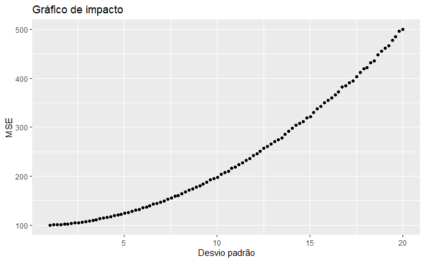

```r
df_vector <- data.frame(std_vector, MSE_vector)
df_vector %>% ggplot() +
  geom_point(aes(x = std_vector, y = MSE_vector)) +
  labs(title = "Gráfico de impacto", x = "Desvio padrão", y = "MSE")
```

• 3) Faça uma análise: o impacto com o aumento ou redução de σ é significativo para o modelo? Qual a justificativa? Quanto maior o desvio padrão maior o MSE. Quanto mais incertezas nos dados o MSE tende a aumentar.